# the anticlust blog

Martin Papenberg

September 13, 2023

## anticlust 0.8.0: The revival of `fast_anticlustering()`

The latest version of `anticlust` (version 0.8.0) was just published on [CRAN](https://cran.r-project.org/package=anticlust). It is mostly concerned with optimizing `anticlust` for (very) large data sets, so most users are probably not affected by the changes. Several internal changes were implemented, which were all triggered by an [issue on Github](https://github.com/m-Py/anticlust/issues/50). This post highlights the – in my opinion – most important changes. You can also read the entire change logs [here](https://m-py.github.io/anticlust/news/).

The most pronounced changes affect the function `fast_anticlustering()`, which was pretty much a second class citizen in `anticlust` ever since `anticlustering()` was re-implemented in C (starting with `anticlust` version 0.5.4 in October 2020). For anticlustering, using C really makes a huge difference in run time as compared to using plain R code. After publishing anticlust 0.5.4, `fast_anticlustering()` was ironically slower than `anticlustering()` and only had limited use cases.[^1] With version 0.8.0, `fast_anticlustering()` is now again the best choice for processing large data sets. This is due to two changes. First, `fast_anticlustering()` now also uses a C implementation. Second, it now uses a different way of re-computing the k-means objective during the optimization process, thereby gaining an order of magnitude in run time. In the following, I will talk about the changed objective for k-means anticlustering.

[The k-means objective](https://en.wikipedia.org/wiki/K-means_clustering) is the “variance”, which is the sum of the squared Euclidean distances between data points and their cluster centers. It can be visualized as follows using the well-known [iris data set](https://en.wikipedia.org/wiki/Iris_flower_data_set):

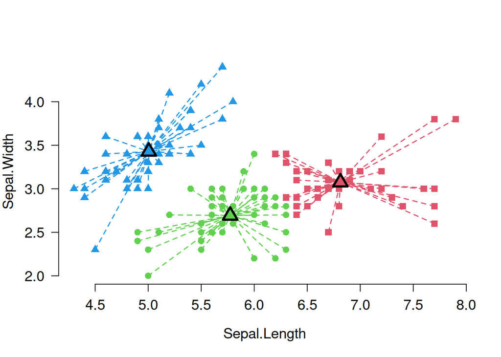

```r
library(anticlust)
kmeans_clusters <- kmeans(iris[, 1:2], centers = 3)$cluster
plot_clusters(iris[, 1:2], kmeans_clusters, illustrate_variance = TRUE, show_axes = TRUE)
```

Here, the `anticlust` function `plot_clusters()` is used to illustrate the k-means objective by highlighting the cluster affiliation (which were obtained by applying the k-means *clustering* algorithm) and the cluster centers (as triangles). While the k-means clustering method *minimizes* the sum of squared distances between cluster centers and data points, k-means *anti*clustering maximizes it. Thereby, k-means anticlustering leads to cluster centers that are very close to each other:

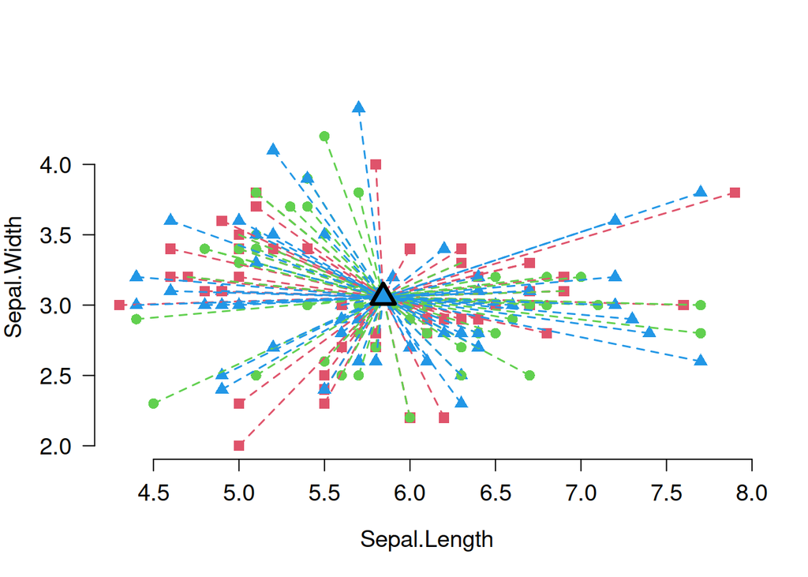

```r
kmeans_anticlusters <- anticlustering(
  iris[, 1:2],
  K = 3,
  objective = "variance" # k-means criterion
)

plot_clusters(iris[, 1:2], kmeans_anticlusters, illustrate_variance = TRUE, show_axes = TRUE)
```

Anticlustering is an iterative method that exchanges data points between clusters repeatedly and re-computes the objective after each exchange. Therefore, computing the distances between data points and cluster centers is the major factor driving the run time of k-means anticlustering. While the cluster centers can be updated rather quickly after an exchange, computing the distances always requires iterating through all data points[^2]. Thus, re-computing the objective depends on the size of the data set *N*, and it has to be done very often during the optimization process. There is a faster way to update the objective, though, which was introduced in `anticlust` 0.8.0: Instead of maximizing the sum of squared distances between cluster centers and data points, it is also possible (and equivalent) to minimize the (weighted) sum of the squared Euclidean distances between cluster centers and the overall centroid. In this case, much fewer distances need to be re-computed during each iteration of the optimization algorithm (in the case of three groups: only three distances). In particular, re-computing the objective the no longer depends on the number of data points $N$. Therefore, we gain an order of magnitude in run time as compared to when computing the variance. However, this is only practically relevant for rather large data sets because for up to several hundred elements, the variance implementation is already very fast.

We can illustrate the difference between computing the two k-means objectives by comparing `anticlustering()` (which computes the variance) and `fast_anticlustering()` (which computes the distances between cluster centers and overall center):

```r
# 1. Compute k-means anticlustering for, N = 500, 2 variables, 5 groups
N <- 500
M <- 2
K <- 5
data <- matrix(rnorm(N * M), ncol = M)

# 1.1 Using the variance computation
system.time(anticlustering(data, K = K, objective = "variance"))
```

```
##        User      System verstrichen
##       0.171       0.000       0.171
```

```r
# 1.2 Using the cluster-center-to-overall-center computation
system.time(fast_anticlustering(data, K = K))
```

```
##        User      System verstrichen
##       0.027       0.004       0.031
```

For N = 500 (which is not a small data set for most anticlustering applications), the new implementation is already much faster than the old one. Still, both versions are very fast and there is no practical gain of using `fast_anticlustering()`. However, let’s see what happens with a larger data set:

```r
# 2. Compute k-means anticlustering for, N = 2000, 2 variables, 5 groups
N <- 2000
M <- 2
K <- 5
data <- matrix(rnorm(N * M), ncol = M)

# 2.1 Using the variance computation
system.time(anticlustering(data, K = K, objective = "variance"))
```

```
##        User      System verstrichen
##      14.182       0.000      14.180
```

```r
# 2.2 Using the cluster-center-to-overall-center computation
system.time(fast_anticlustering(data, K = K))
```

```
##        User      System verstrichen
##       0.519       0.052       0.571
```

When N gets larger, gaining an order of magnitude of computation time makes a huge difference. Usually, for large data sets, we would also specify the argument `k_neighbours` when using `fast_anticlustering()`, which then gains another order of magnitude in run time. Then, we can even process 1 million data points in a few minutes. The user `viv-analytics`, [who opened the Github](https://github.com/m-Py/anticlust/issues/50) issue reporting that anticlustering fails for large N, reported that the old R implementation of `fast_anticlustering()` took about 6000 seconds (almost two hours) for processing about 295k data points with 2 numeric variables. Let’s see how that works using the new `anticlust` version:

```r
N <- 295000
M <- 2
K <- 2
data <- matrix(rnorm(N * M), ncol = M)
system.time(fast_anticlustering(data, K = K, k_neighbours = 2))
```

```
##        User      System verstrichen
##      12.907       0.113      13.018
```

About 13 seconds vs. about 6000 seconds – what an improvement!

To conclude, some questions remain as to why the improved computation is not also implemented in `anticlustering()` for the objectives `"variance"` and `"kplus"`, and `kplus_anticlustering()`. While this may be done in the future, there are some reasons that prevented me from already doing it with the current release:

1. The standard function `anticlustering(..., objective = "variance")` – and hence, `anticlustering(..., objective = "kplus")` – does run quickly for most practical sizes of data sets and its implementation has proven stable over several years. I cannot say for sure that the new implementation is as stable and as free of bugs.
2. The functions `fast_anticlustering()` and `anticlustering()` have a different handling of categorical variables (passed via the argument `categories`). In `anticlustering()`, I would like to keep the handling that has been used previously. So, some work would remain to port the code used in `fast_anticlustering()` to `anticlustering()`.
3. Technically, it would be incorrect to use the new implementation for `objective = "variance"` because the *variance* is no longer computed. It might be possible to introduce a new option `objective = "kmeans"` that uses the new computation. I am leaning towards this option, because I have wanted the option `objective = "kmeans"` in `anticlustering()` for some time anyway. Frankly, I am no longer happy with the name `objective = "variance"` and I would prefer `objective = "kmeans"`. For backwards compatibility, I would still keep `objective = "variance"` in future versions. I think that including `objective = "kmeans"` as part of a different computation would be quite elegant.

Last updated: 2023-09-14

### Back to the front page

[^1]: The function `fast_anticlustering()` has an improved theoretical run time (by an order of magnitude) because the optimization algorithm can employ fewer iterations. For very large data sets, this improved theoretical run time outweighs the worse implementation (R vs. C). However, this only relevant for very large data sets. Still: at least one user profited from `fast_anticlustering()` using the old R implementation, as evident from the [issue on Github](https://github.com/m-Py/anticlust/issues/50).
[^2]: Or at least the data points that are currently assigned to the two groups that are affected by the exchange.